# Journal Club Notes

# Objective:

1. present Hwang et al. (2018) as a journal club to the joint Simons-Cooperstone labs

## Present:

1. Read the papers, *describe* the **general methodologies** used and **data** presented, and *summarize* it and its **findings**
2. What do these findings *mean* for **your own** research?

From Jess:  
Hi Matthiew – I’d like to see you select one of the two papers I asked you to read and create a journal club like presentation describing what is done in the paper, and **highlighting how this work is relevant to your research**. I was you to understand the *basics of their methods* and the *implications of their findings*. You can focus on the coffee relevant parts of the paper to make it more manageable. You and Chris can think together about what a reasonable timeline to put this together would be.

I’m concerned there are some **fundamentals about genetic control of bitterness perception (including basics about what a gene is, what genetic variation really means, what a bitter receptor is)** as well as what **implication** this has for your project and how you attempt to control for this in your studies. I’d like to be sure this is something you are understanding moving forward.

From Jess:  
Hi Matthiew – good to hear back about this – I was thinking to follow up about this recently so your ears must have been burning. What I’d like you to understand is:

- What is a SNP
- What can allelic variation in a SNP (or indels) lead to
- How conceptually variants in sequence could lead to differences in bitter perception
- That you understand the central dogma of biology at least in concept

I’m less worried that you understand how to do functional annotation, just that you get the sort of concept of how you would. How is it that you could confirm that a particular variant leads to a functional outcome?

# Outline:

## Introduction

### Why am I doing this?

- a gap identified during candidacy exam (something I was never taught in undergrad)

## PROP Case Study

Definitions - can use PROP as example

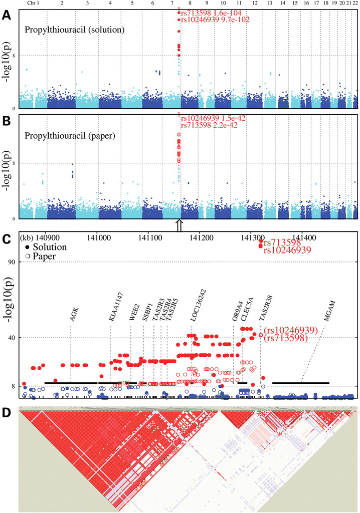

PROP signal, chromosome 7. Figure 1 from Reed et al. (2010)

- 3 SNPs (Robino et al. (2022))
  - PAV haplotype = “taster”
    - PAV refers to amino acids proline-alanine-valine
  - AVI haplotype = “nontaster”
    - AVI refers to amino acids alanine-valine-isoleucine
  - haplotype refers to a group of SNPS that usually reside near each other on a chromosome ([genome.gov](https://www.genome.gov/genetics-glossary/haplotype))
- SNP rs10246939
  - explains ~50% of observed variance in detection thresholds (Genick et al. (2011))
  - MAF 46% (Genick et al. (2011))
    - Chris mentioned that because it is “ubiquitous”, there is generally some associated advantage to this SNP as to why it wasn’t slowly removed through natural selection
- other factors influencing PROP perception (Robino et al. (2022))
  - fungiform pappilae count/density
  - age
  - gender
  - salivary flow rate and protein composition

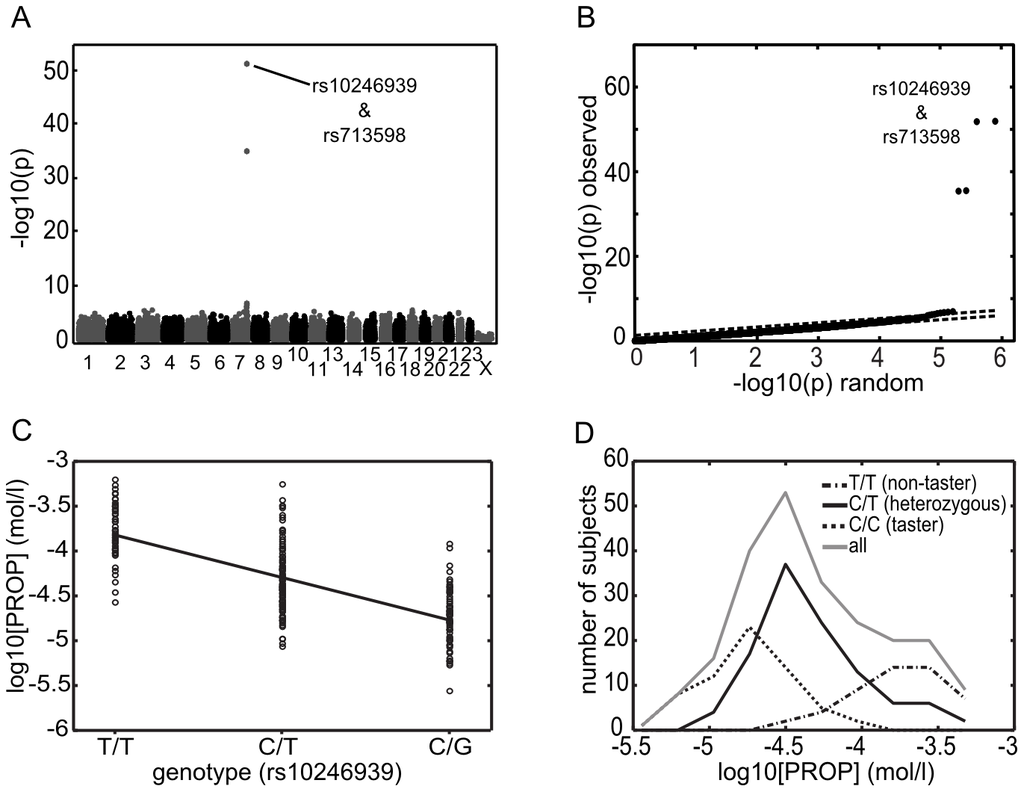

Figure 4 from Genick et al. (2011). Panels C and D how the relationship between PROP sensitivity and genotype at rs10246939

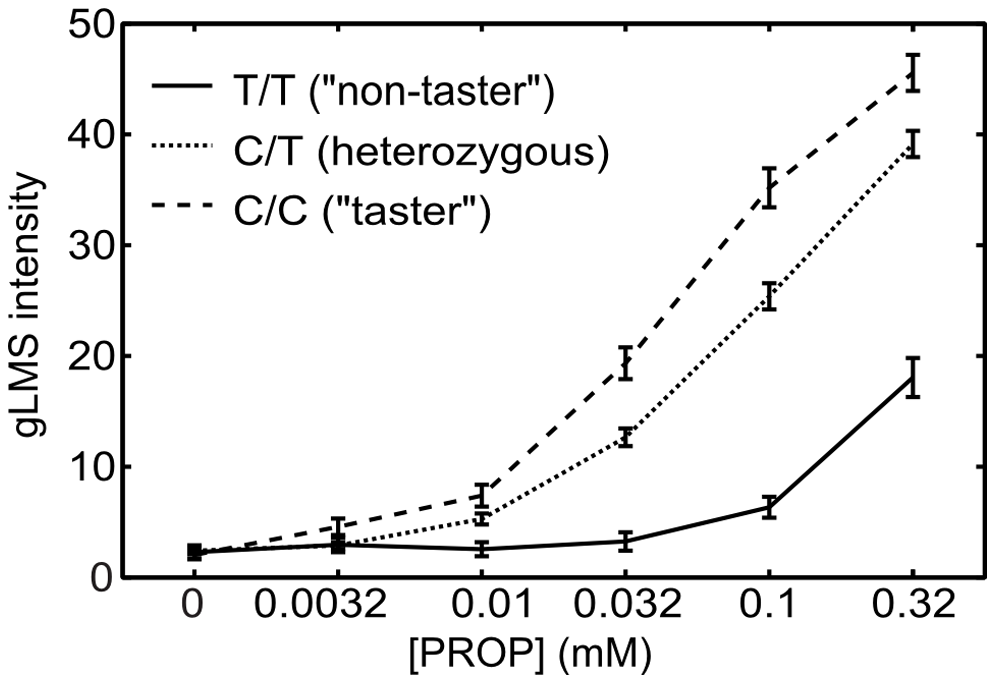

Figure 7 from Genick et al. (2011) showing the average perceived gLMS intensity ($\pm$) SEM for each genotype oat SNP rs10246939

- Previous GWAS (Reed et al. (2010)) showed signal at TAS2R38 (rs10246939)
  - also showed TAS2R19 for quinine on chromosome 12
  - NS for caffeine/SOA
  - no other proposed loci for PROP on chromosomes 5 or 16

## Hwang et al. (2018)

### Intro/Background

#### 1. describe a problem

- bitterness is a basic taste, but isn’t perceived the same way for everyone
- 36-73% of bitterness perception is due to genetics (Hwang et al. (2018))
  - *what are some explanations of variability outside of genetic reasons?*

#### 2. describe a question

- PROP bitterness has been implicated in fat perception (Tepper and Nurse (1997))
- PTC related to diseases (Guo and Reed (2001)), immune system, and surgical outcome of severe rhinosinusitis (Hwang et al. (2018))
- want to understand “underlying genetic variation that leads to individual differences in bitter perception”
  - this could have implications in “personalized medicine” (Hwang et al. (2018); Bush and Moore (2012))

#### 3. describe other’s responses

- Previous GWAS (Reed et al. (2010)) replicated association between *TAS2R38* and PROP perception
  - and identified a SNP within *TAS2R19*: accounting for 5.8% of variance in quinine perception
  - did not find loci for caffeine, SOA, or proposed second locus for PTC/PROP, suggested/proposed signals on chromosomes 5 and 16

#### 4. explain a need for a new/novel approach

- use multivariate association analysis to find common genetic variants (MAF $\ge$ 5%) with small effects
- can identify *pleiotropic* genetic variants
- can identify variants with only one of the correlated phenotypes
- using MV GWAS can find associations that didn’t reach significance in univariate analysis

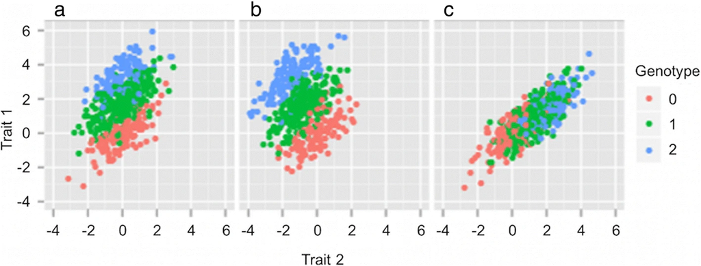

**Figure 1**

- 1A: spread on y axis, not on x axis
  - only T1 (y axis) is associated with variant (non-pleiotropic)
  - better separation seen in 2D (practice with the pencil test from high school math class)
- 1B: spread on y and x axis
  - minor allele has opposing effects, $\uparrow$ T1 (Y) and $\downarrow$ T2 (X)
  - starting to see the spread on y and x axes, especially when combined
- 1C: minor allele has similar effects, $\uparrow$ T1 (Y) and $\uparrow$ T2 (X)
  - no greater separation with bivariate analysis than would get with univariate

#### 5. say your aim

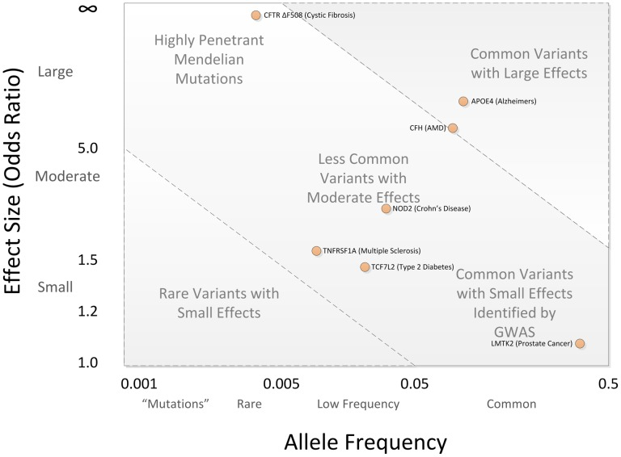

**Figure 1**

### Methods

#### Taste Perception

- described in Hansen et al. (2006)
  - this paper doesn’t explicitly say how much volume each sample was
  - previous GWAS (Reed et al. (2010)) used 1 ML solution
    - implications/limitations of this?
- presented 5 bitter samples with reps
  - $2*10^{-4}\ M$ SOA
  - $1.81*10^{-4}\ M$ quinine HCl
  - $0.050 \ M$ caffeine
  - $6.0*10^{-4}\ M$ PROP
  - $4.99*10^{-6}\ M$ denatonium benzoate
  - same order presentation for all participants
- swish and spit after 5 s, rate on LMS
- bitter scores were square root transformed then converted to z-scores

#### GWAS

- described in Hwang et al. (2018)
  - supplemental underpinings of GWAS from Bush and Moore (2012)
- 1999 Caucasians from Europe, including twins and siblings
  - this is an increase in sample size from Hansen et al. (2006) by 40%
- used p < $5 * 10^{-8}$ for genome wide significance
  - used a Bonferroni corrected p < $1*10^{-8}$

##### Modeling

- linear mixed model
  - covariates (fixed effects): age, sex, ear infection history, first 5 PC from genotype
  - used additive model (cf. Bush and Moore (2012))
- bivariate analysis can complement univariate analysis
  - can enhance the strength of a SNP association, but not effect size Hwang et al. (2018)
- variance explained by SNP was calculated as $2* MAF* (1-MAF)* \beta^2$

##### Functional annotation of identified SNPs

- functional annotation can be used to identify any potential roles of the identified SNPs
  - could be used to identify/develop mechanistic hypotheses in understanding variance in taste perception based on the identified/associates SNPs

### Results

- *focus on PROP and caffeine*

### Discussion

#### Implications of *their* research

#### Implications of *my* research

# Notes

- read references 26 and 29 in Hwang et al

# References

Bush, William S., and Jason H. Moore. 2012. “Chapter 11: Genome-Wide Association Studies.” Edited by Fran Lewitter and Maricel Kann. *PLoS Comput Biol* 8 (12): e1002822. https://doi.org/10.1371/journal.pcbi.1002822.

Genick, Ulrich K, Zoltán Kutalik, Mirko Ledda, Maria C Souza Destito, Milena M Souza, Cintia A Cirillo, Nicolas Godinot, et al. 2011. “Sensitivity of Genome-Wide-Association Signals to Phenotyping Strategy: The PROP-TAS2R38 Taste Association as a Benchmark.” *PLoS One* 6 (11): e27745.

Guo, Sun-Wei, and Danielle Reed. 2001. “The Genetics of Phenylthiocarbamide Perception.” *Annals of Human Biology* 28 (2): 111–42. https://doi.org/10.1080/03014460151056310.

Hansen, J. L., Danielle Reed, Margaret Wright, Nicholas Martin, and Paul Breslin. 2006. “Heritability and Genetic Covariation of Sensitivity to Prop, SOA, Quinine Hcl, and Caffeine.” *Chemical Senses* 31 (5): 403–13. https://doi.org/10.1093/chemse/bjj044.

Hwang, Liang-Dar, Puya Gharahkhani, Paul A. S. Breslin, Scott D. Gordon, Gu Zhu, Nicholas G. Martin, Danielle R. Reed, and Margaret J. Wright. 2018. “Bivariate Genome-Wide Association Analysis Strengthens the Role of Bitter Receptor Clusters on Chromosomes 7 and 12 in Human Bitter Taste.” *BMC Genomics* 19 (1): 678. https://doi.org/10.1186/s12864-018-5058-2.

Reed, Danielle R, Gu Zhu, Paul A S Breslin, Fujiko F Duke, Anjali K Henders, Megan J Campbell, Grant W Montgomery, Sarah E Medland, Nicholas G Martin, and Margaret J Wright. 2010. “The Perception of Quinine Taste Intensity Is Associated with Common Genetic Variants in a Bitter Receptor Cluster on Chromosome 12.” *Hum. Mol. Genet.* 19 (21): 4278–85.

Robino, Antonietta, Maria Pina Concas, Sara Spinelli, Lapo Pierguidi, Beverly J Tepper, Paolo Gasparini, John Prescott, et al. 2022. “Combined Influence of TAS2R38 Genotype and PROP Phenotype on the Intensity of Basic Tastes, Astringency and Pungency in the Italian Taste Project.” *Food Qual. Prefer.* 95 (104361): 104361.

Tepper, Beverly J., and Ricky J. Nurse. 1997. “Fat Perception Is Related to PROP Taster Status.” *Physiology and Behavior* 61 (6): 949–54. https://doi.org/10.1016/S0031-9384(96)00608-7.